# Úvod do dátovej analýzy v R

Toto je R Markdown dokument, ktorý umožňuje do obyčajného textu vkladať kusy kódu v R, napr. takto:

```r
summary(cars)
```

```
##      speed           dist
##  Min.   : 4.0   Min.   :  2.00
##  1st Qu.:12.0   1st Qu.: 26.00
##  Median :15.0   Median : 36.00
##  Mean   :15.4   Mean   : 42.98
##  3rd Qu.:19.0   3rd Qu.: 56.00
##  Max.   :25.0   Max.   :120.00
```

Následne je možné skompilovať ho do HTML, PDF, Latex alebo MS Word dokumentu. Viac informácií o R Markdowne nájdete na http://rmarkdown.rstudio.com.

## Čo je R

R je jeden z najpoužívanejších jazykov pre dátovú analýzu. Vznikol ako dialekt jazyka S, ktorý bol vyvinutý Johnom Chambersom v Bell Laboratories v roku 1976 ako interné štatistické prostredie, pôvodne vo Fortrane, neskôr bol prepísaný do C-čka. R je implementáciou jazyka S z roku 1991. Jazyk je neustále vyvíjaný aktívnou komunitou; momentálne existuje vyše 13000 balíčkov dostupných v [CRAN archíve](https://cran.r-project.org/).

## Základné príkazy

Aktuálny pracovný adresár zistíme nasledovne:

```r
getwd()
```

```
## [1] "D:/OneDrive/Dokumenty/PhD/Vyucba/VOS/2018"
```

```r
# Zmeniť ho vieme pomcou príkazu setwd()
```

Dokumentáciu k nejakej funkcii, napr. `rnorm`, ktorá slúži na vygenerovanie náhodnej hodnoty z normálneho rozdelenia, si vyvoláme pomocou:

```r
?rnorm
```

```
## starting httpd help server ... done
```

```r
# alternatívne: help("rnorm")
```

Ak nevieme presný názov, môžeme skúsiť vyhľadávať:

```r
??rnor
# alternatívne: help.search("rnor")
```

Balíček načítame pomocou príkazu `library`:

```r
library(ggplot2)
# ak ho nemáme, musíme ho najprv nainštalovať: install.packages("ggplot2")
```

Priradenie hodnoty do premennej funguje pomocou operátora `<-`, ale dá sa použiť aj klasické `=`:

```r
x <- 5 + 2
print(x)
```

```
## [1] 7
```

## Základné dátové typy

Atomické dátové typy sú `character`, `numeric`, `integer`, `complex`, `logical`.

```r
class(x)
```

```
## [1] "numeric"
```

```r
is.numeric(x)
```

```
## [1] TRUE
```

```r
is.integer(x) == TRUE
```

```
## [1] FALSE
```

```r
is.integer(10L)
```

```
## [1] TRUE
```

```r
as.character(x)
```

```
## [1] "7"
```

Špeciálne hodnoty:

```r
1/0
```

```
## [1] Inf
```

```r
is.numeric(-Inf)
```

```
## [1] TRUE
```

```r
Inf - Inf
```

```
## [1] NaN
```

```r
is.nan(Inf)
```

```
## [1] FALSE
```

```r
is.nan(NaN)
```

```
## [1] TRUE
```

```r
is.na(NA)
```

```
## [1] TRUE
```

### Vektor

Všetko vo vektore musí byť rovnakého typu, `vector()` vytvorí prázdny vektor.

```r
v1 <- c(1, 2, 3, 4)
v1
```

```
## [1] 1 2 3 4
```

```r
v2 <- 1:4
v2
```

```
## [1] 1 2 3 4
```

```r
v3 <- seq(1, 4, by = 1)
v3
```

```
## [1] 1 2 3 4
```

```r
v1[1]
```

```
## [1] 1
```

Dĺžka vektora:

```r
length(v1)
```

```
## [1] 4
```

### Zoznam (list)

Zoznam (list) je vektor, resp. sekvencia objektov, v ktorej každý môže byť iný (rôzneho typu).

```r
l <- list(
  name = "Robert",
  surname = "Moro",
  age = 27,
  seminars = c("VOS", "MIP")
)

print(l)
```

```
## $name
## [1] "Robert"
##
## $surname
## [1] "Moro"
##
## $age
## [1] 27
##
## $seminars
## [1] "VOS" "MIP"
```

Pristupovanie k prvkom zoznamu:

```r
print(l$name)
```

```
## [1] "Robert"
```

```r
l[1]
```

```
## $name
## [1] "Robert"
```

```r
l[[1]]
```

```
## [1] "Robert"
```

```r
l[["name"]]
```

```
## [1] "Robert"
```

Vlastnosti zoznamu:

```r
length(l)
```

```
## [1] 4
```

```r
names(l)
```

```
## [1] "name"     "surname"  "age"      "seminars"
```

### Matica

Matica sa vytvára funkciou `matrix()`. Štandardne sa napĺňa po stĺpcoch, dá sa zmeniť pomocou parametra `byrow`.

```r
m <- matrix(nrow = 2, ncol = 3)
m
```

```
##      [,1] [,2] [,3]
## [1,]   NA   NA   NA
## [2,]   NA   NA   NA
```

```r
dim(m)
```

```
## [1] 2 3
```

```r
attributes(m)
```

```
## $dim
## [1] 2 3
```

```r
m <- matrix(1:6, nrow = 2, ncol = 3)
m
```

```
##      [,1] [,2] [,3]
## [1,]    1    3    5
## [2,]    2    4    6
```

Maticu vieme spraviť aj z vektora:

```r
m <- 1:10
dim(m) <- c(2, 5)
m
```

```
##      [,1] [,2] [,3] [,4] [,5]
## [1,]    1    3    5    7    9
## [2,]    2    4    6    8   10
```

Iný spôsob je zviazať dokopy stĺpce alebo riadky:

```r
x <- 1:3
y <- 10:12
cbind(x, y)
```

```
##      x  y
## [1,] 1 10
## [2,] 2 11
## [3,] 3 12
```

```r
rbind(x, y)
```

```
##   [,1] [,2] [,3]
## x    1    2    3
## y   10   11   12
```

### Faktor

Faktor je špeciálny dátový typ, ktorý umožňuje efektívne reprezentovať nominálne (kategorické) premenné. Typický príklad je pohlavie, ktoré môžu nadobúdať hodnoty M (male) alebo F (female). Môžeme ho reprezentovať pomocou reťazcov:

```r
sex <- c("male", "male", "female", "male", "female")
sex
```

```
## [1] "male"   "male"   "female" "male"   "female"
```

Toto je však pamäťovo (a pri niektorých operáciách, napr. zistení počtu unikátnych hodnôt, aj časovo) neefektívne. Taktiež je to náchylné na preklepy.

Faktor umožňuje takýto reťazec reprezentovať pomocou čísel:

```r
sex_f <- as.factor(sex)
sex_f
```

```
## [1] male   male   female male   female
## Levels: female male
```

```r
levels(sex_f)
```

```
## [1] "female" "male"
```

```r
str(sex_f)
```

```
##  Factor w/ 2 levels "female","male": 2 2 1 2 1
```

```r
as.integer(sex_f)
```

```
## [1] 2 2 1 2 1
```

### Data.Frame

Podobný typ ako matica, ale umožňuje, aby mal každý stĺpec iný typ. Slúži na reprezentáciu tabuľkových dát.

```r
df <- data.frame(name = c("Jozko", "Robo", "Jakub"),
                 has_phd = c(TRUE, FALSE, FALSE),
                 sex = factor(c("male", "male", "male")))

dimnames(df)
```

```
## [[1]]
## [1] "1" "2" "3"
##
## [[2]]
## [1] "name"    "has_phd" "sex"
```

```r
nrow(df)
```

```
## [1] 3
```

```r
dim(df)
```

```
## [1] 3 3
```

```r
head(df)
```

```
##    name has_phd  sex
## 1 Jozko    TRUE male
## 2  Robo   FALSE male
## 3 Jakub   FALSE male
```

```r
str(df)
```

```
## 'data.frame':    3 obs. of  3 variables:
##  $ name   : Factor w/ 3 levels "Jakub","Jozko",..: 2 3 1
##  $ has_phd: logi  TRUE FALSE FALSE
##  $ sex    : Factor w/ 1 level "male": 1 1 1
```

```r
summary(df)
```

```
##     name    has_phd          sex
##  Jakub:1   Mode :logical   male:3
##  Jozko:1   FALSE:2
##  Robo :1   TRUE :1
```

```r
df[1,]
```

```
##    name has_phd  sex
## 1 Jozko    TRUE male
```

```r
df[,1]
```

```
## [1] Jozko Robo  Jakub
## Levels: Jakub Jozko Robo
```

```r
df[, "has_phd"]
```

```
## [1]  TRUE FALSE FALSE
```

```r
df$has_phd
```

```
## [1]  TRUE FALSE FALSE
```

```r
df[["has_phd"]]
```

```
## [1]  TRUE FALSE FALSE
```

```r
df[df$has_phd == TRUE,]
```

```
##    name has_phd  sex
## 1 Jozko    TRUE male
```

Výstup do CSV:

```r
write.csv(df, "lecturers.csv", row.names = FALSE)
```

Načítanie z csv:

```r
df <- read.csv("lecturers.csv")
df
```

```
##    name has_phd  sex
## 1 Jozko    TRUE male
## 2  Robo   FALSE male
## 3 Jakub   FALSE male
```

## Funkcionálne prvky jazyka

V Rku je funkcia občanom prvej triedy. To znamená, že ju môžeme uložiť do premennej, môže byť argumentom inej funkcie alebo funkcia môže vrátiť inú funkciu. Dole je uvedených zopár príkladov väčšinou prebratých alebo inšpirovaných knihou [Advanced R](http://adv-r.had.co.nz) od Hadleyho Wickhama. Pre viac informácií a príkladov pozrite jeho online dostupnú knihu.

```r
a_func <- function(f, vec) f(vec)

x <- c(1, 2, 3)

a_func(sum, x)
```

```
## [1] 6
```

```r
a_func(mean, x)
```

```
## [1] 2
```

Funkcia, ktorá berie ako jeden z argumentov funkciu, sa nazýva *funkcionál*. Najčastejšie používanými funkcionálmi v Rku su `lapply`, `apply`, `sapply` a `tapply`.

```r
unlist(lapply(mtcars, class))
```

```
##       mpg       cyl      disp        hp      drat        wt      qsec
## "numeric" "numeric" "numeric" "numeric" "numeric" "numeric" "numeric"
##        vs        am      gear      carb
## "numeric" "numeric" "numeric" "numeric"
```

```r
mtcars2 <- data.frame(lapply(mtcars, function(x) x / mean(x)))
head(mtcars2)
```

```
##         mpg       cyl      disp        hp      drat        wt      qsec
## 1 1.0452636 0.9696970 0.6934756 0.7498935 1.0843688 0.8143601 0.9221934
## 2 1.0452636 0.9696970 0.6934756 0.7498935 1.0843688 0.8936203 0.9535682
## 3 1.1348577 0.6464646 0.4680961 0.6340009 1.0704666 0.7211128 1.0426500
## 4 1.0651734 0.9696970 1.1182295 0.7498935 0.8563733 0.9993006 1.0891519
## 5 0.9307824 1.2929293 1.5603202 1.1930124 0.8758363 1.0692361 0.9535682
## 6 0.9009177 0.9696970 0.9752001 0.7158074 0.7673994 1.0754526 1.1328524
##         vs       am      gear      carb
## 1 0.000000 2.461538 1.0847458 1.4222222
## 2 0.000000 2.461538 1.0847458 1.4222222
## 3 2.285714 2.461538 1.0847458 0.3555556
## 4 2.285714 0.000000 0.8135593 0.3555556
## 5 0.000000 0.000000 0.8135593 0.7111111
## 6 2.285714 0.000000 0.8135593 0.3555556
```

R obsahuje aj klasické `Map`, `Reduce` a `Filter` funkcie.

```r
# Vahovany priemer
xs <- replicate(5, runif(10), simplify = FALSE)
ws <- replicate(5, rpois(10, 5) + 1, simplify = FALSE)
unlist(Map(weighted.mean, xs, ws))
```

```
## [1] 0.6121055 0.4071340 0.4514322 0.5647210 0.5135709
```

```r
Reduce(`+`, 1:3)
```

```
## [1] 6
```

```r
Reduce(sum, 1:3)
```

```
## [1] 6
```

```r
df <- data.frame(x = 1:3, y = c("a", "b", "c"))
str(Filter(is.factor, df))
```

```
## 'data.frame':    3 obs. of  1 variable:
##  $ y: Factor w/ 3 levels "a","b","c": 1 2 3
```

## Užitočné knižnice

### dplyr

Uľahčuje manipuláciu s dátami pomocou funkcií, ktoré vychádzajú z SQL.

```r
library(dplyr)
df <- read.csv(file = 'fitts.csv')
df$A <- factor(df$A)
df$W <- factor(df$W)
df$Block <- factor(df$Block)
str(df)
```

```
## 'data.frame':    36 obs. of  19 variables:
##  $ Participant: Factor w/ 9 levels "m01","M02","M03",..: 1 1 1 1 2 2 2 2 3 3 ...
##  $ Block      : Factor w/ 4 levels "1","2","3","4": 1 2 3 4 1 2 3 4 1 2 ...
##  $ Group      : Factor w/ 1 level "etdata": 1 1 1 1 1 1 1 1 1 1 ...
##  $ Condition  : Factor w/ 2 levels "Mouse","Space": 1 1 1 1 1 1 1 1 1 1 ...
##  $ Task       : Factor w/ 1 level "2D": 1 1 1 1 1 1 1 1 1 1 ...
##  $ Response   : Factor w/ 1 level "Serial": 1 1 1 1 1 1 1 1 1 1 ...
##  $ A          : Factor w/ 2 levels "150","300": 1 1 2 2 1 1 2 2 1 1 ...
##  $ W          : Factor w/ 2 levels "40","80": 1 2 1 2 1 2 1 2 1 2 ...
##  $ ID         : num  2.25 1.52 3.09 2.25 2.25 ...
##  $ N          : int  9 11 9 10 11 11 11 11 11 11 ...
##  $ Skewness   : num  -0.406 0.678 0.57 0.228 0.453 ...
##  $ Kurtosis   : num  0.157 1.959 0.345 -0.833 -0.924 ...
##  $ IsNormal   : Factor w/ 2 levels "False","True": 1 1 1 1 1 1 1 1 1 2 ...
##  $ Ae         : num  301 370 661 655 365 ...
##  $ We         : num  20.6 64.6 33.1 67.8 35.1 ...
##  $ IDe        : num  3.97 2.75 4.39 3.41 3.51 ...
##  $ MT         : num  756 608 655 759 1160 ...
##  $ Misses     : int  0 0 0 0 0 0 0 0 0 0 ...
##  $ Throughput : num  5.25 4.52 6.71 4.5 3.03 ...
```

```r
head(df)
```

```
##   Participant Block  Group Condition Task Response   A  W       ID  N
## 1         m01     1 etdata     Mouse   2D   Serial 150 40 2.247928  9
## 2         m01     2 etdata     Mouse   2D   Serial 150 80 1.523562 11
## 3         m01     3 etdata     Mouse   2D   Serial 300 40 3.087463  9
## 4         m01     4 etdata     Mouse   2D   Serial 300 80 2.247928 10
## 5         M02     1 etdata     Mouse   2D   Serial 150 40 2.247928 11
## 6         M02     2 etdata     Mouse   2D   Serial 150 80 1.523562 11
##    Skewness  Kurtosis IsNormal       Ae       We      IDe        MT Misses
## 1 -0.405962  0.156672    False 300.8731 20.56631 3.966192  755.8270      0
## 2  0.678419  1.958662    False 369.8698 64.61187 2.749424  608.3420      0
## 3  0.570330  0.344771    False 661.2799 33.05597 4.392651  654.5202      0
## 4  0.228273 -0.833430    False 654.8114 67.79106 3.414035  758.5064      0
## 5  0.452734 -0.923589    False 365.2085 35.10033 3.511557 1159.7912      0
## 6  0.011228 -1.818751    False 353.8437 38.47824 3.349924 1277.8723      0
##   Throughput
## 1   5.247487
## 2   4.519537
## 3   6.711253
## 4   4.500997
## 5   3.027749
## 6   2.621485
```

```r
dfM <- filter(df, Condition == "Mouse")
dfS <- filter(df, Condition == "Space")

df.grouped <- df %>% group_by(Participant, Condition) %>% summarise(Throughput = mean(Throughput))
head(df.grouped)
```

```
## # A tibble: 6 x 3
## # Groups:   Participant [6]
##   Participant Condition Throughput
##   <fct>       <fct>          <dbl>
## 1 m01         Mouse          5.24
## 2 M02         Mouse          3.19
## 3 M03         Mouse          4.77
## 4 M05         Mouse          4.10
## 5 S01         Space          0.879
## 6 s02         Space          1.05
```

### data.table

Alternatíva na manipuláciu s dátami. Umožňuje efektívne pracovať s veľkými datasetmi. Oplatí sa tak investovať čas do naučenia na prvý pohľad nie vždy intuitívnej syntaxe. Odporúčam pozrieť intro tu: https://cran.r-project.org/web/packages/data.table/vignettes/datatable-intro.html

```r
library(data.table)
df2 <- data.table(df)

head(df2[Condition == "Mouse" & Block == 1])
```

```
##    Participant Block  Group Condition Task Response   A  W       ID  N
## 1:         m01     1 etdata     Mouse   2D   Serial 150 40 2.247928  9
## 2:         M02     1 etdata     Mouse   2D   Serial 150 40 2.247928 11
## 3:         M03     1 etdata     Mouse   2D   Serial 150 40 2.247928 11
## 4:         M05     1 etdata     Mouse   2D   Serial 150 40 2.247928 11
##     Skewness  Kurtosis IsNormal       Ae       We      IDe       MT Misses
## 1: -0.405962  0.156672    False 300.8731 20.56631 3.966192  755.827      0
## 2:  0.452734 -0.923589    False 365.2085 35.10033 3.511557 1159.791      0
## 3: -0.473521 -1.524342    False 369.1239 31.41548 3.672397 1014.413      0
## 4: -0.216488 -1.244271    False 362.7464 45.29500 3.171292  800.681      1
##    Throughput
## 1:   5.247487
## 2:   3.027749
## 3:   3.620220
## 4:   3.960743
```

```r
df2[Condition == "Mouse" & Block == 1, .N]
```

```
## [1] 4
```

```r
df2[, .(Throughput = mean(Throughput)), by =.(Participant, Condition)]
```

```
##    Participant Condition Throughput
## 1:         m01     Mouse  5.2448185
## 2:         M02     Mouse  3.1881732
## 3:         M03     Mouse  4.7739607
## 4:         M05     Mouse  4.1040218
## 5:         S01     Space  0.8786867
## 6:         s02     Space  1.0489840
## 7:         S03     Space  0.5791435
## 8:         S04     Space  0.4481793
## 9:         S05     Space  1.0290710
```

### ggplot2

Veľmi silná knižnica na tvorbu vizualizácií dát.

```r
library(ggplot2)
```

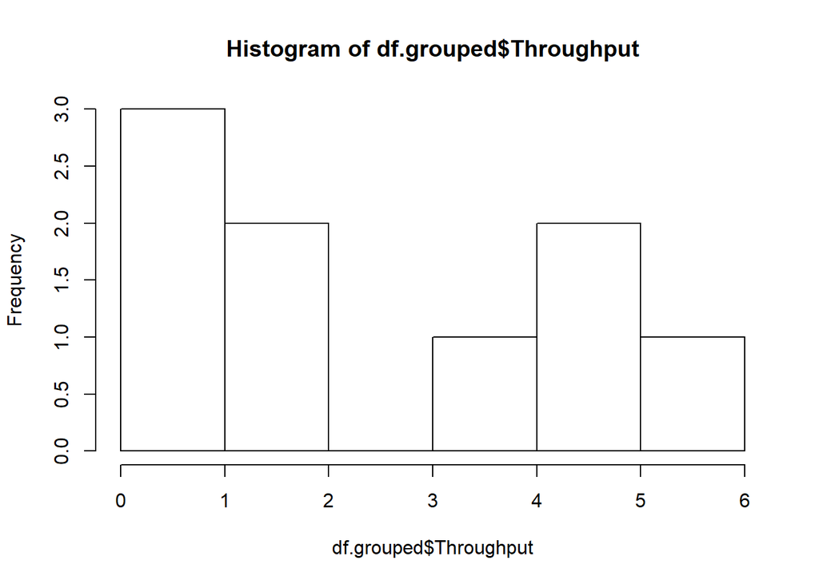

```r
hist(df.grouped$Throughput)
```

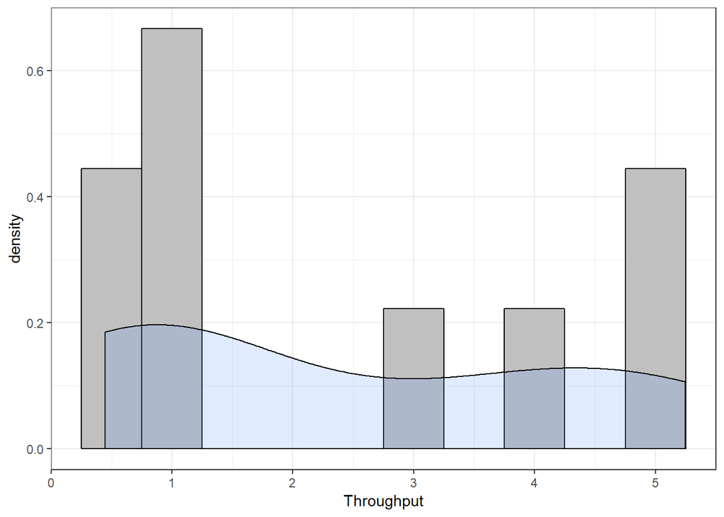

```r
ggplot(df.grouped, aes(x=Throughput)) +
  geom_histogram(aes(y = ..density..), binwidth = .5, colour="black", fill="#C0C0C0") +
  geom_density(alpha=.2, fill="#6699FF") +
  theme_bw()
```

```r
library(afex)
fit <- aov_ez(data = df, id = "Participant", dv = "Throughput", between = "Condition", within = c("A", "W"))
```

```
## Contrasts set to contr.sum for the following variables: Condition
```

```r
lsCond <- lsmeans(fit, "Condition")
```

```
## NOTE: Results may be misleading due to involvement in interactions
```

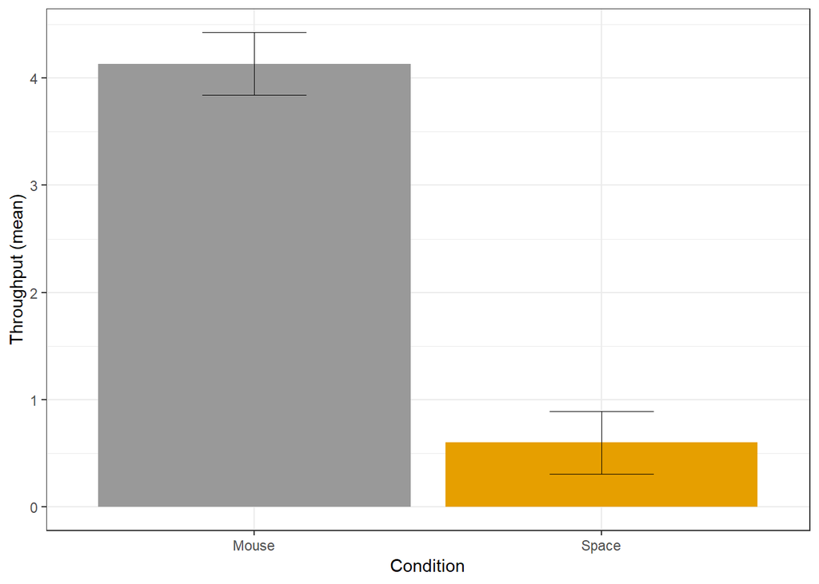

```r
tab <- summary(lsCond)

ggplot(data=tab, aes(x=Condition, y=lsmean, fill=Condition)) +
  geom_bar(stat="identity", position=position_dodge()) +
  geom_errorbar(aes(ymin=lsmean-SE, ymax=lsmean+SE), width=.3, size=.3,position=position_dodge(0)) +
  scale_fill_manual(values=c("#999999", "#E69F00")) +
  theme_bw() +
  theme(legend.position = "none") +
  ylab("Throughput (mean)")
```

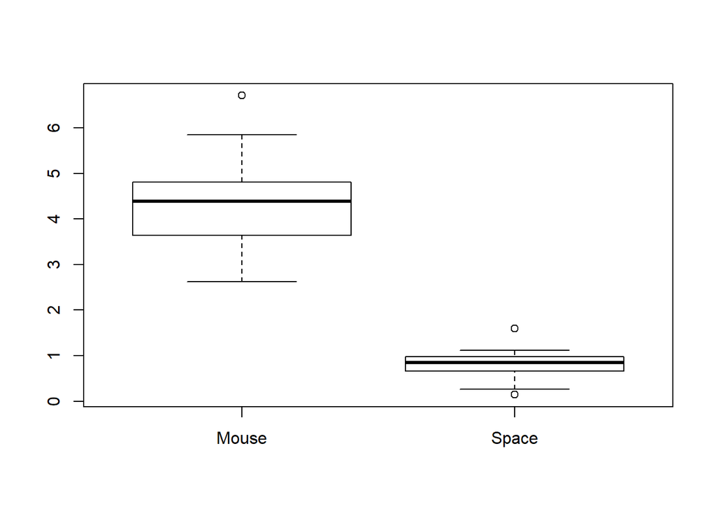

```r
boxplot(Throughput ~ Condition, df)
```

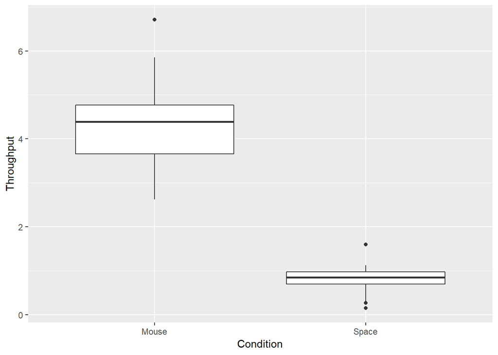

```r
ggplot(data = df, aes(x = Condition, y = Throughput)) + geom_boxplot(position = "dodge2") #+theme_bw()
```

### caret

Je to knižnica na trénovanie modelov strojového učenia. Odporúčam pozrieť dokumentáciu: http://topepo.github.io/caret/index.html